# COM747 Week 4: Inferential Statistics and Hypothesis Testing

Lecturer demonstration notebook

# Today’s question

> **Do female and male students get different final grades?**

> In `student_data.csv` the mean G3 is 9.97 for female and 10.91 for male students. Is that a **real** difference in the population of students, or could it just be **sampling error**? Today we learn how to decide, and how not to fool ourselves.

**Learning outcomes**

1. Explain sampling error and the standard error of the mean.
2. Calculate and interpret a confidence interval.
3. Carry out a hypothesis test and interpret the p-value.
4. Choose the right test: t-tests, Wilcoxon, chi-square (prop.test), ANOVA.
5. Explain Type I and II errors, power, effect size and multiple testing.

```r
rundata  <- read.csv("rundata.csv")
students <- read.csv("student_data.csv")
```

# Part 1: Population versus sample

> We almost never see the whole **population**. We see a **sample** and use it to **infer** something about the population. Different samples give different answers: **sampling error**.

**PREDICT** True mean is 50, SD 20. Will a sample of 5 give a mean close to 50? A sample of 1,000?

```r
set.seed(4)
x5    <- rnorm(5, 50, 20);    c(mean = mean(x5), sd = sd(x5))
```

```
##     mean       sd
## 61.18802 16.12827
```

```r
x1000 <- rnorm(1000, 50, 20); c(mean = mean(x1000), sd = sd(x1000))
```

```
##     mean       sd
## 49.27826 19.40446
```

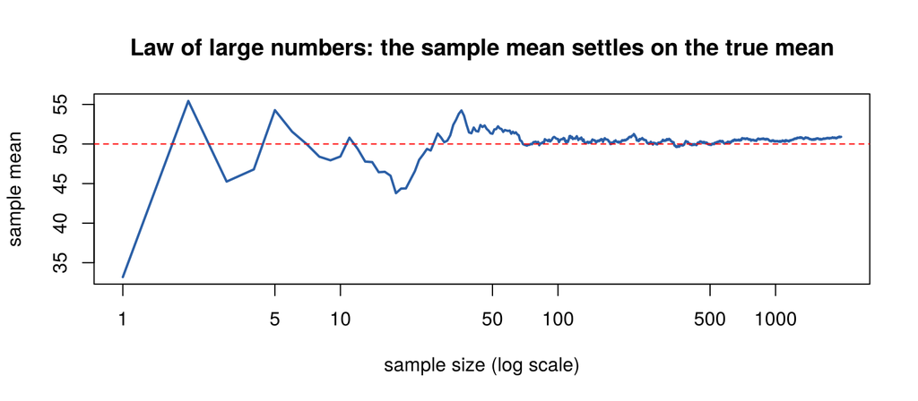

```r
set.seed(5)
x <- rnorm(2000, 50, 20)
running_mean <- cumsum(x) / seq_along(x)
plot(running_mean, type = "l", col = "#2b5fa6", lwd = 2, log = "x",
     xlab = "sample size (log scale)", ylab = "sample mean",
     main = "Law of large numbers: the sample mean settles on the true mean")
abline(h = 50, lty = 2, col = "red")
```

### Sampling methods

| Method | How | Risk |
| --- | --- | --- |
| Simple random | every member equally likely | can miss small groups by chance |
| Stratified | random within groups (e.g. campus) | needs group sizes known |
| Convenience | whoever is easy to reach | bias: not representative |

# Part 2: Standard error and confidence intervals

$$SE = \frac{s}{\sqrt{n}}$$

> The **standard error** is the SD of the sample means (the width of the CLT histogram last week). Bigger samples → smaller SE → more precise estimates.

### Worked example from the lecture

Sample mean 75, SD 18, n = 36.

```r
se <- 18 / sqrt(36); se                 # 3
```

```
## [1] 3
```

```r
75 + c(-1, 1) * 1 * se                  # 68% CI: 72 to 78
```

```
## [1] 72 78
```

```r
75 + c(-1, 1) * 1.96 * se               # 95% CI: 69.12 to 80.88
```

```
## [1] 69.12 80.88
```

> Report as: **75 (95% CI 69.12 to 80.88)**. Margin of error = 5.88.

### Small samples: use the t-distribution

```r
qnorm(0.975)          # 1.96
```

```
## [1] 1.959964
```

```r
qt(0.975, df = 14)    # 2.145 for n = 15
```

```
## [1] 2.144787
```

```r
qt(0.975, df = 29)    # 2.045 for n = 30
```

```
## [1] 2.04523
```

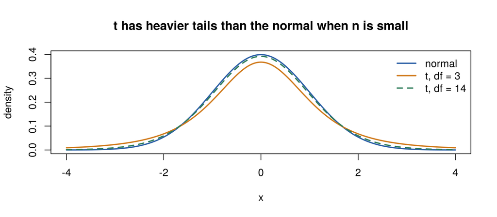

```r
x <- seq(-4, 4, length.out = 300)
plot(x, dnorm(x), type = "l", lwd = 2, col = "#2b5fa6", ylab = "density",
     main = "t has heavier tails than the normal when n is small")
lines(x, dt(x, df = 3),  lwd = 2, col = "#d0791a")
lines(x, dt(x, df = 14), lwd = 2, col = "#2f7d5b", lty = 2)
legend("topright", c("normal", "t, df = 3", "t, df = 14"), col = c("#2b5fa6", "#d0791a", "#2f7d5b"),
       lwd = 2, lty = c(1, 1, 2), bty = "n")
```

### A confidence interval three ways

```r
heights <- c(40, 42, 55, 40, 49, 46, 42, 50, 54, 44, 40, 42, 46, 48, 52, 45, 48, 44, 39, 38, 45)
n  <- length(heights)
m  <- mean(heights)
se <- sd(heights) / sqrt(n)
tc <- qt(0.975, df = n - 1)

# 1. by hand
c(lower = m - tc * se, upper = m + tc * se)
```

```
##    lower    upper
## 42.96226 47.41869
```

```r
# 2. with t.test()
t.test(heights, conf.level = 0.95)$conf.int
```

```
## [1] 42.96226 47.41869
## attr(,"conf.level")
## [1] 0.95
```

```r
# 3. a reusable function
ci <- function(x, level = 0.95) {
  se <- sd(x) / sqrt(length(x)); tc <- qt(1 - (1 - level) / 2, length(x) - 1)
  c(mean = mean(x), lower = mean(x) - tc * se, upper = mean(x) + tc * se)
}
ci(heights); ci(heights, 0.99)
```

```
##     mean    lower    upper
## 45.19048 42.96226 47.41869
```

```
##     mean    lower    upper
## 45.19048 42.15110 48.22986
```

### What “95% confidence” really means

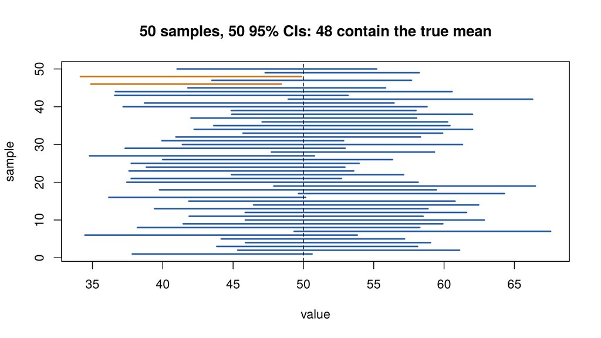

```r
set.seed(3)
true_mean <- 50
cis <- t(replicate(50, ci(rnorm(25, true_mean, 20))))
miss <- cis[, "lower"] > true_mean | cis[, "upper"] < true_mean
plot(NULL, xlim = range(cis[, 2:3]), ylim = c(1, 50), xlab = "value", ylab = "sample",
     main = paste0("50 samples, 50 95% CIs: ", sum(!miss), " contain the true mean"))
segments(cis[, "lower"], 1:50, cis[, "upper"], 1:50, col = ifelse(miss, "#d0791a", "#2b5fa6"), lwd = 2)
abline(v = true_mean, lty = 2)
```

> If we repeated the study many times, **95% of the intervals** would contain the true mean. Any single interval either does or doesn’t.

**→ STUDENTS:** Week 4 page: CI simulator, then Core tasks.

# Part 3: The hypothesis-testing recipe

1. State **H0** (no difference / no effect) and **H1** (there is a difference).
2. Choose **alpha**, usually 0.05.
3. Check **assumptions**: normality (`shapiro.test`), equal variances (largest/smallest variance < 1.5, or `var.test`).
4. Choose and run the test → **test statistic** and **p-value**.
5. If **p < alpha**, reject H0. Report the effect size and a confidence interval too.

> **p-value:** the probability of getting a result at least this extreme **if H0 were true**. It is *not* the probability that H0 is true.

```r
shapiro.test(students$G3)                       # not normal (the zeros)
```

```
##
##  Shapiro-Wilk normality test
##
## data:  students$G3
## W = 0.92873, p-value = 8.836e-13
```

```r
tapply(students$G3, students$sex, var)          # 21.4 vs 20.2: ratio 1.06 < 1.5
```

```
##        F        M
## 21.36601 20.20769
```

```r
var.test(G3 ~ sex, data = students)$p.value     # no evidence of unequal variances
```

```
## [1] 0.698872
```

# Part 4: t-tests

### One-sample: is the mean first run different from 30 km?

```r
t.test(rundata$FirstRun, mu = 30)
```

```
##
##  One Sample t-test
##
## data:  rundata$FirstRun
## t = -1.3158, df = 98, p-value = 0.1913
## alternative hypothesis: true mean is not equal to 30
## 95 percent confidence interval:
##  26.83873 30.64046
## sample estimates:
## mean of x
##   28.7396
```

**Ask:** p = 0.19. What do we conclude? (We **fail to reject** H0. That is not the same as proving the mean is 30.)

### Paired: did the same runners run further the second time?

```r
t.test(rundata$FirstRun, rundata$SecondRun, paired = TRUE)
```

```
##
##  Paired t-test
##
## data:  rundata$FirstRun and rundata$SecondRun
## t = -23.986, df = 98, p-value < 2.2e-16
## alternative hypothesis: true mean difference is not equal to 0
## 95 percent confidence interval:
##  -5.650776 -4.787204
## sample estimates:
## mean difference
##        -5.21899
```

```r
diffs <- rundata$SecondRun - rundata$FirstRun
shapiro.test(diffs)                      # paired test assumes the differences are normal
```

```
##
##  Shapiro-Wilk normality test
##
## data:  diffs
## W = 0.99209, p-value = 0.8325
```

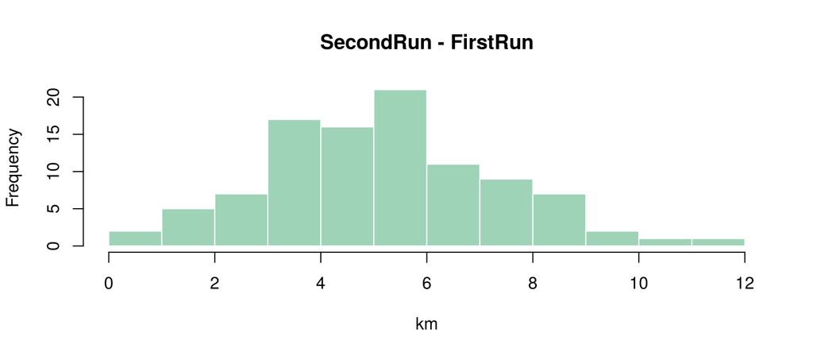

```r
hist(diffs, col = "#9fd3b8", border = "white", main = "SecondRun - FirstRun", xlab = "km")
```

### Independent (Welch): do grades differ by sex?

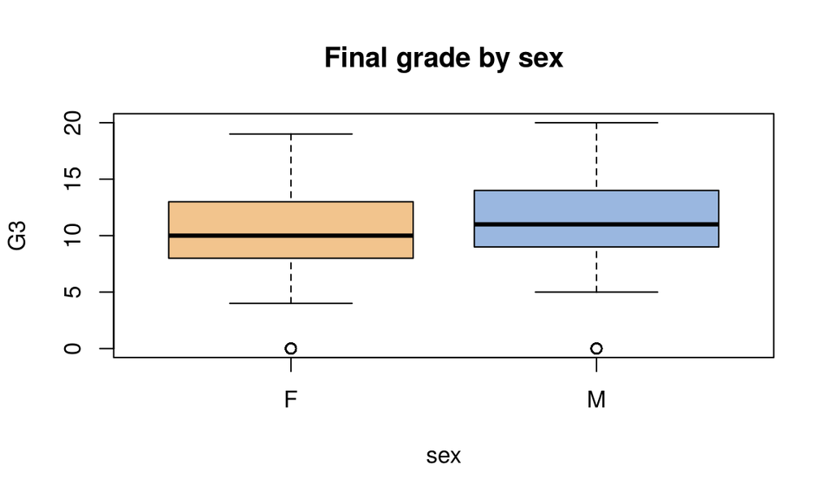

```r
boxplot(G3 ~ sex, data = students, col = c("#f2c48d", "#9ab7e0"), main = "Final grade by sex")
```

```r
t.test(G3 ~ sex, data = students)        # Welch by default: does not assume equal variances
```

```
##
##  Welch Two Sample t-test
##
## data:  G3 by sex
## t = -2.0651, df = 390.57, p-value = 0.03958
## alternative hypothesis: true difference in means between group F and group M is not equal to 0
## 95 percent confidence interval:
##  -1.85073226 -0.04545244
## sample estimates:
## mean in group F mean in group M
##        9.966346       10.914439
```

### Non-parametric alternative: Wilcoxon / Mann–Whitney

```r
wilcox.test(G3 ~ sex, data = students, exact = FALSE)
```

```
##
##  Wilcoxon rank sum test with continuity correction
##
## data:  G3 by sex
## W = 17138, p-value = 0.04065
## alternative hypothesis: true location shift is not equal to 0
```

**Ask:** p = 0.040. Significant at 0.05. But remove the 38 zeros (students who left) and run it again:

```r
no_zeros <- students[students$G3 > 0, ]
t.test(G3 ~ sex, data = no_zeros)$p.value     # 0.053
```

```
## [1] 0.05334761
```

> One reasonable data-cleaning decision flips the conclusion. Decide your cleaning rules **before** testing, report what you did, and don’t hunt for p < 0.05 (**p-hacking**).

### Effect size: Cohen’s d

```r
cohens_d <- function(x, y) abs(mean(x) - mean(y)) / sqrt((var(x) + var(y)) / 2)
cohens_d(students$G3[students$sex == "F"], students$G3[students$sex == "M"])   # 0.21: small
```

```
## [1] 0.2079487
```

> Small = 0.2, medium = 0.5, large = 0.8. Statistically significant ≠ a big difference.

# Part 5: Proportions, many groups, relationships

### Chi-square / test of proportions (A/B testing)

25 of 30 people liked website A; 5 of 31 liked website B.

```r
prop.test(x = c(25, 5), n = c(30, 31))
```

```
##
##  2-sample test for equality of proportions with continuity correction
##
## data:  c(25, 5) out of c(30, 31)
## X-squared = 24.927, df = 1, p-value = 5.955e-07
## alternative hypothesis: two.sided
## 95 percent confidence interval:
##  0.4533774 0.8907087
## sample estimates:
##    prop 1    prop 2
## 0.8333333 0.1612903
```

### ANOVA: more than two groups

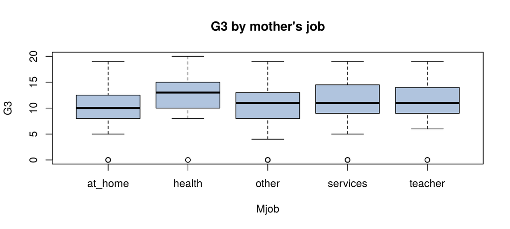

```r
boxplot(G3 ~ Mjob, data = students, col = "lightsteelblue", main = "G3 by mother's job")
```

```r
summary(aov(G3 ~ Mjob, data = students))
```

```
##              Df Sum Sq Mean Sq F value  Pr(>F)
## Mjob          4    307   76.66   3.754 0.00519 **
## Residuals   390   7963   20.42
## ---
## Signif. codes:  0 '***' 0.001 '**' 0.01 '*' 0.05 '.' 0.1 ' ' 1
```

> ANOVA tells you *some* group differs, not which. Follow up with `pairwise.t.test(students$G3, students$Mjob, p.adjust.method = "bonferroni")`.

### Correlation

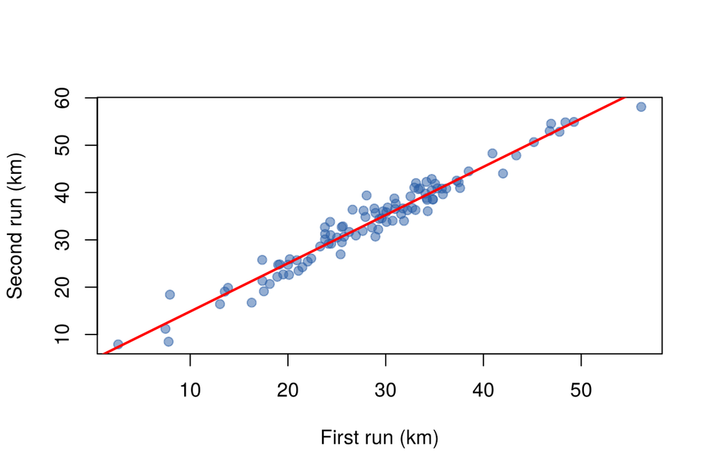

```r
plot(rundata$FirstRun, rundata$SecondRun, pch = 19, col = "#2b5fa680",
     xlab = "First run (km)", ylab = "Second run (km)")
abline(lm(SecondRun ~ FirstRun, data = rundata), col = "red", lwd = 2)
```

```r
cor(rundata$FirstRun, rundata$SecondRun)
```

```
## [1] 0.9762012
```

```r
cor.test(rundata$FirstRun, rundata$SecondRun)
```

```
##
##  Pearson's product-moment correlation
##
## data:  rundata$FirstRun and rundata$SecondRun
## t = 44.333, df = 97, p-value < 2.2e-16
## alternative hypothesis: true correlation is not equal to 0
## 95 percent confidence interval:
##  0.9647003 0.9839856
## sample estimates:
##       cor
## 0.9762012
```

```r
cor(rundata)          # which runs correlate most?
```

```
##            FirstRun SecondRun  FinalRun
## FirstRun  1.0000000 0.9762012 0.9261859
## SecondRun 0.9762012 1.0000000 0.9607919
## FinalRun  0.9261859 0.9607919 1.0000000
```

# Part 6: Errors, power and multiple testing

|  | H0 true | H0 false |
| --- | --- | --- |
| **Reject H0** | Type I error (false positive), probability α | Correct: power = 1 − β |
| **Don’t reject** | Correct | Type II error (false negative), probability β |

> Court analogy: Type I = convicting an innocent person; Type II = acquitting a guilty one.

### Power by simulation (from the lecture)

```r
power_sim <- function(samplesize, meanX, meanY, sdX = 5, sdY = 5, studies = 1000) {
  pvalues <- replicate(studies, t.test(rnorm(samplesize, meanX, sdX), rnorm(samplesize, meanY, sdY))$p.value)
  mean(pvalues < 0.05)
}
set.seed(8)
power_sim(200, 50, 51)    # d = 0.2, n = 200: about 51%
```

```
## [1] 0.504
```

```r
power_sim(500, 50, 51)    # d = 0.2, n = 500: about 88%
```

```
## [1] 0.879
```

```r
power_sim(50,  50, 55)    # d = 1.0, n = 50: almost 100%
```

```
## [1] 0.999
```

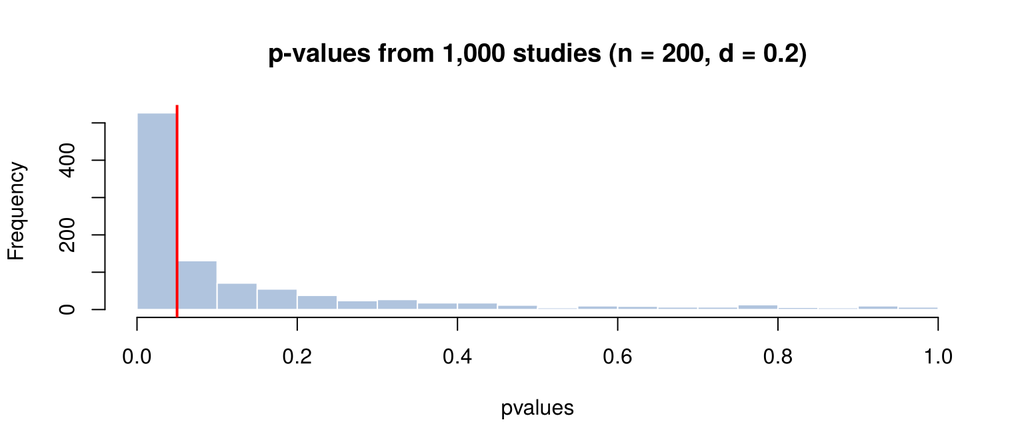

```r
pvalues <- replicate(1000, t.test(rnorm(200, 50, 5), rnorm(200, 51, 5))$p.value)
hist(pvalues, breaks = 20, col = "lightsteelblue", border = "white", main = "p-values from 1,000 studies (n = 200, d = 0.2)")
abline(v = 0.05, col = "red", lwd = 2)
```

### Sample size before you collect data

```r
power.t.test(power = 0.80, delta = 0.5, sd = 1, type = "two.sample")   # about 64 per group
```

```
##
##      Two-sample t test power calculation
##
##               n = 63.76576
##           delta = 0.5
##              sd = 1
##       sig.level = 0.05
##           power = 0.8
##     alternative = two.sided
##
## NOTE: n is number in *each* group
```

### Multiple testing and the Bonferroni correction

```r
set.seed(2)
# 20 tests where H0 is TRUE every time
p <- replicate(20, t.test(rnorm(30), rnorm(30))$p.value)
sum(p < 0.05)                 # "discoveries" that are false positives
```

```
## [1] 2
```

```r
0.05 / 20                     # Bonferroni alpha: 0.0025
```

```
## [1] 0.0025
```

```r
sum(p < 0.05 / 20)
```

```
## [1] 0
```

```r
p.adjust(p, method = "bonferroni")[1:5]
```

```
## [1] 1 1 1 1 1
```

> “If you torture the data long enough, it will confess to anything.” Pre-register your hypotheses, avoid HARKing (hypothesising after results are known), correct for multiple tests.

# Choosing a test

| Question | Data | Test in R |
| --- | --- | --- |
| One mean vs a value | numeric, ~normal | `t.test(x, mu = )` |
| Same people measured twice | paired numeric | `t.test(x, y, paired = TRUE)` / `wilcox.test(..., paired = TRUE)` |
| Two independent groups | numeric | `t.test(y ~ group)` (Welch) / `wilcox.test(y ~ group)` |
| Three or more groups | numeric | `aov()` / `kruskal.test()` |
| Two proportions | counts | `prop.test()` / `chisq.test()` |
| Relationship | two numeric | `cor.test()` (Pearson) / `cor.test(method = "spearman")` |
| Is it normal? | numeric | `shapiro.test()` |

**Next week:** regression: from “are these related?” to “predict one from the other”.